# Situacion Problema

Sebastian Diaz y Lya Ximena Castrejón

12 de junio de 2025

# Análisis de variantes de COVID BA.1 (2021) y JN.1 (2024): ¿Qué cambio en el virus a traves de los años?

### Las muestras analizadas se recolectaron el país de Estados Unidos, así que este estudio se enfocara en ese contexto geográfico.

Se decidió utilizar estas 2 variantes del virus SARS-COV2 ya que fueron las más predominantes en sus respectivos años, generando más cantidad de datos para analizar y así garantizar un analísis contundente.Para practicidad de este proyecto se decidió trabajar con 80 secuencias de cada variante, debido a limitantes técnicos.

## Análisis del Gen “S”

Para está primera parte del análisis decidimos separar el gen S para analizarlo de manera individual, debido a que está proteína es clave para la infectividad, la Spike es responsable de que el virus pueda infectar células humanas, así que si existen cambios en el gen S pueden mejorar la afinidad del virus por los receptores humanos, aumentando su transmisibilidad.A su vez de esta manera se podrá analizar si las mutaciones generan que el virus puede escapar parcialmente a la inmunidad generada por vacunas o infecciones previas.

```r
library(seqinr)
library(ggplot2)
library(dplyr)

trad =    c(UUU="F", UUC="F", UUA="L", UUG="L",
            UCU="S", UCC="S", UCA="S", UCG="S",
            UAU="Y", UAC="Y", UAA="STOP", UAG="STOP",
            UGU="C", UGC="C", UGA="STOP", UGG="W",
            CUU="L", CUC="L", CUA="L", CUG="L",
            CCU="P", CCC="P", CCA="P", CCG="P",
            CAU="H", CAC="H", CAA="Q", CAG="Q",
            CGU="R", CGC="R", CGA="R", CGG="R",
            AUU="I", AUC="I", AUA="I", AUG="M",
            ACU="T", ACC="T", ACA="T", ACG="T",
            AAU="N", AAC="N", AAA="K", AAG="K",
            AGU="S", AGC="S", AGA="R", AGG="R",
            GUU="V", GUC="V", GUA="V", GUG="V",
            GCU="A", GCC="A", GCA="A", GCG="A",
            GAU="D", GAC="D", GAA="E", GAG="E",
            GGU="G", GGC="G", GGA="G", GGG="G")

datos= data.frame(
  mutacion = character(),
  cambioCodon = character(),
  cambioAmino = character(),
  pos = integer(),
  gen = character(),
  stringsAsFactors = FALSE
)

file = read.fasta("BA.1_2021.fasta", forceDNAtolower = FALSE)
file2 = read.fasta("JN.1_2024.fasta", forceDNAtolower = FALSE)
#vs = length(file2)/12

BA.1= file[sapply(file, function(x) grepl("surface glycoprotein", attr(x, "Annot")))]
JN.1= file2[sapply(file2, function(x) grepl("surface glycoprotein", attr(x, "Annot")))]

BA.1 <- BA.1[1:80]
JN.1 <- JN.1[1:80]
cat("Secuencias BA.1 2021:", length(BA.1), "\n")
```

```
## Secuencias BA.1 2021: 80
```

```r
cat("Secuencias JN.1 2024:", length(JN.1), "\n")
```

```
## Secuencias JN.1 2024: 80
```

```r
nMut=1


for (i in seq_along(BA.1)){
  gen = BA.1[[i]]
  gen[which(gen=="T")]="U"

for (j in seq_along(JN.1)){
    gen2 = JN.1[[j]]

    gen2[which(gen2=="T")]="U"

    if (length(gen) == length(gen2)){
      diff = which(gen!=gen2)
      if (length(diff)>0){
        prevMut=""
        for (pos in diff){
          ini = pos - (pos-1)%%3
          if (ini + 2 > length(gen)) next
          mutacion = paste(gen[pos], "to", gen2[pos], sep="")
          codOri = paste(gen[ini],gen[ini+1],gen[ini+2],sep="")
          codMut = paste(gen2[ini],gen2[ini+1],gen2[ini+2],sep="")
          codonChange = paste(codOri,"to",codMut,sep="")
          nCod = ((pos-1)%/%3) + 1
          aminoChange = paste(trad[codOri],nCod,trad[codMut],sep="")
          if (!is.na(trad[codMut]) && !is.na(trad[codOri]) &&
              trad[codOri] != trad[codMut]) {
            datos[nMut, ] = list(mutacion,codonChange,aminoChange, nCod, "S")
            nMut = nMut + 1
          }
          prevMut = aminoChange
        }
      }
    }
  }
}
```

## Cambio de Nucleótidos en el gen S

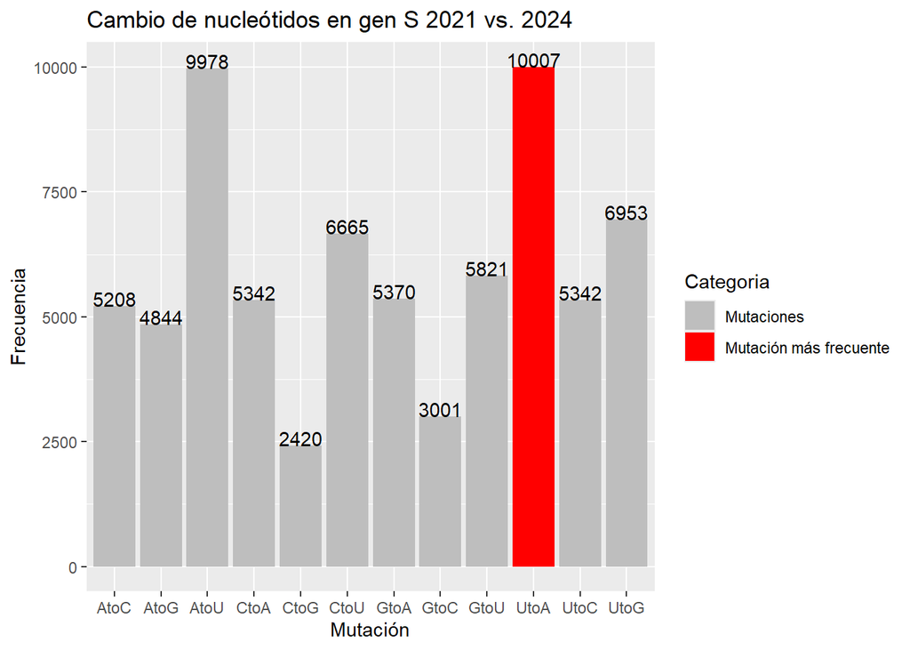

```r
#Gráfica 1 Cambio de Nucleótidos

frecuencias = datos %>%
  group_by(cambioAmino) %>%
  summarise(frecuencia = n()) %>%
  arrange(desc(frecuencia))

mutaciones_frecuentes = datos %>%
  count(mutacion, sort = TRUE) %>%
  filter(n == max(n))

datos$resaltada= datos$mutacion %in% mutaciones_frecuentes$mutacion

p = ggplot(datos)
p = p + aes(x = mutacion, fill = resaltada, label = after_stat(count))
p = p + ggtitle(paste("Cambio de nucleótidos en gen S 2021 vs. 2024"))
p = p + labs(x = "Mutación", y = "Frecuencia", fill = "Categoria")
p = p + geom_bar(stat = "count")
p = p + geom_text(stat = "count", vjust = 0)
p = p + scale_fill_manual(values = c("gray", "red"), labels = c("Mutaciones","Mutación más frecuente"))
p
```

Al comparar las variantes BA.1 (2021) y JN.1 (2024) del gen S, pudimos observar que las mutaciones más frecuentes son U→A (10,007 casos) y A→U (9,978).Estos cambios muestran un patrón claro: las mutaciones que involucran el nucleótido uracilo (U) son predominantes.

Biológicamente, esto indica una alta inestabilidad del ARN viral en esas posiciones, posiblemente por procesos como la desaminación o presión selectiva.La repetición frecuente de estas mutaciones sugiere que el virus está adaptándose para mejorar su capacidad de infección o evasión del sistema inmune, especialmente en la variante JN.1.

En particular, el predominio de la mutación U→A en 2024 podría estar relacionado con cambios estructurales clave en la proteína S que favorecen una mayor transmisibilidad o resistencia a anticuerpos.

### Gráfico Pastel Nucleótidos gen “S”

A continuación se genero un gráfico de pastel donde se observa de manera más intuitiva el porcentaje de cambios de nucleótidos entre ambas variantes. El gráfico refleja una fuerte tendencia del SARS-CoV-2 a acumular mutaciones del tipo transición A↔︎U y C→U, lo que sugiere mecanismos comunes de mutagénesis en virus ARN. Esta distribución no es aleatoria, y revela una adaptación del virus a presiones biológicas específicas en su evolución entre 2021 y 2024.

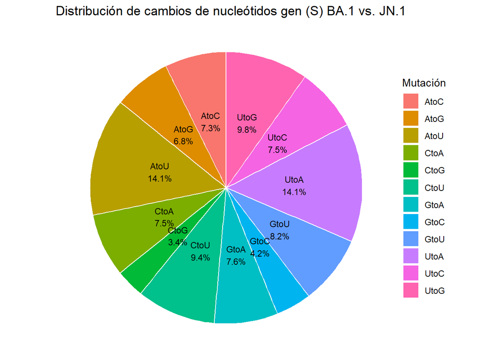

```r
frecuencias_nt = datos %>%
  count(mutacion, sort = TRUE) %>%
  mutate(porcentaje = n / sum(n) * 100)

frecuencias_nt$etiqueta = ifelse(frecuencias_nt$porcentaje > 3,
                                  paste0(frecuencias_nt$mutacion, "\n", round(frecuencias_nt$porcentaje, 1), "%"),"")
p_nt = ggplot(frecuencias_nt, aes(x = "", y = porcentaje, fill = mutacion)) +
  geom_col(width = 1, color = "white") +
  coord_polar(theta = "y") +
  geom_text(aes(label = etiqueta),
            position = position_stack(vjust = 0.5), size = 3) +
  labs(title = "Distribución de cambios de nucleótidos gen (S) BA.1 vs. JN.1",
       fill = "Mutación") +
  theme_void()
p_nt
```

## Cambio de Aminoácidos en el gen S

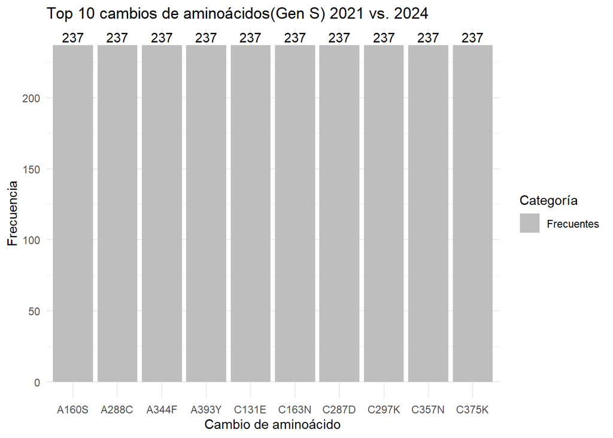

```r
# GRAFICA 2: CAMBIO DE AMINOACIDO QUE MAS SE REPITE

library(dplyr)

dfgraph <- datos %>%
  group_by(cambioAmino) %>%
  summarise(
    mutacion = first(mutacion),
    cambioCodon = first(cambioCodon),
    pos = first(pos),
    gen = first(gen),
    cuenta = n(),
    .groups = "drop"
  ) %>%
  arrange(desc(cuenta)) %>%
  slice_head(n = 10)

max_val <- max(dfgraph$cuenta)
dfgraph$resaltado <- dfgraph$cuenta == max_val

p3 <- ggplot(dfgraph)
p3 <- p3 + aes(x = reorder(cambioAmino, -cuenta), y = cuenta, fill = resaltado, label = cuenta)
p3 <- p3 + ggtitle("Top 10 cambios de aminoácidos(Gen S) 2021 vs. 2024")
p3 <- p3 + labs(x = "Cambio de aminoácido", y = "Frecuencia", fill = "Categoría")
p3 <- p3 + geom_bar(stat = "identity")
p3 <- p3 + geom_text(stat = "identity", vjust = -0.3)
p3 <- p3 + scale_fill_manual(values = c("gray", "red"), labels = c("Frecuentes", "Más frecuente"))
p3 <- p3 + theme_minimal()
print(p3)
```

Comparando las variantes BA.1 (2021) y JN.1 (2024) del gen S, les agregamos un filtro para que los 10 cambios de aminoácidos más frecuentes aparezcan en la gráfica, probablemente hay más que cambios de aminoácidos que cuentan con la misma cantidad o cercana pero ya no entran en la gráfica debido al filtro. Los cambios que se pueden ver en la gráfica, todos aparecen con la misma frecuencia (237 casos cada uno), lo que indica que están presentes de forma constante en la variante JN.1. Con esta repetición sugiere que dichas mutaciones están fijadas en la nueva variante y forman parte de su identidad genética.

Muchos de estos cambios afectan residuos de cisteína (C), un aminoácido crucial para la formación de puentes disulfuro (son uniones químicas que se forman entre dos átomos de azufre), que son esenciales para mantener la estructura de la proteína Spike. Al alterarse esta estructura, el virus podría modificar su forma de unirse al receptor ACE2 o evadir con mayor eficacia los anticuerpos generados por vacunas o infecciones previas.Estos cambios tienen un impacto potencial en la eficacia de las vacunas actuales, ya que modifican regiones clave de la proteína Spike, que es el principal blanco de la respuesta inmune.

## Análisis del Gen “M”

Posteriormente analizamos el gen M de manera individual, este gen pertenece a una de las cuatro proteínas estructurales del COVID, esta proteína es escencial para el ensamblaje del virus. Las pocas mutaciones que ocurren en el gen M suelen ser funcionalmente relevantes. Cambios en este proteína puede influir indirectamente en la transmisibilidad o severidad de la infección.

```r
library(seqinr)
library(ggplot2)
library(dplyr)

trad =    c(UUU="F", UUC="F", UUA="L", UUG="L",
            UCU="S", UCC="S", UCA="S", UCG="S",
            UAU="Y", UAC="Y", UAA="STOP", UAG="STOP",
            UGU="C", UGC="C", UGA="STOP", UGG="W",
            CUU="L", CUC="L", CUA="L", CUG="L",
            CCU="P", CCC="P", CCA="P", CCG="P",
            CAU="H", CAC="H", CAA="Q", CAG="Q",
            CGU="R", CGC="R", CGA="R", CGG="R",
            AUU="I", AUC="I", AUA="I", AUG="M",
            ACU="T", ACC="T", ACA="T", ACG="T",
            AAU="N", AAC="N", AAA="K", AAG="K",
            AGU="S", AGC="S", AGA="R", AGG="R",
            GUU="V", GUC="V", GUA="V", GUG="V",
            GCU="A", GCC="A", GCA="A", GCG="A",
            GAU="D", GAC="D", GAA="E", GAG="E",
            GGU="G", GGC="G", GGA="G", GGG="G")

datos2= data.frame(
  mutacion = character(),
  cambioCodon = character(),
  cambioAmino = character(),
  pos = integer(),
  gen = character(),
  stringsAsFactors = FALSE
)

file = read.fasta("BA.1_2021.fasta", forceDNAtolower = FALSE)
file2 = read.fasta("JN.1_2024.fasta", forceDNAtolower = FALSE)
#vs = length(file2)/12

BA.1= file[sapply(file, function(x) grepl("membrane glycoprotein", attr(x, "Annot")))]
JN.1= file2[sapply(file2, function(x) grepl("membrane glycoprotein", attr(x, "Annot")))]

BA.1 <- BA.1[1:80]
JN.1 <- JN.1[1:80]
cat("Secuencias BA.1 2021:", length(BA.1), "\n")
cat("Secuencias JN.1 2024:", length(JN.1), "\n")

nMut=1


for (i in seq_along(BA.1)){
  gen = BA.1[[i]]
  gen[which(gen=="T")]="U"

for (j in seq_along(JN.1)){
    gen2 = JN.1[[j]]

    gen2[which(gen2=="T")]="U"

    if (length(gen) == length(gen2)){
      diff = which(gen!=gen2)
      if (length(diff)>0){
        prevMut=""
        for (pos in diff){
          ini = pos - (pos-1)%%3
          if (ini + 2 > length(gen)) next
          mutacion = paste(gen[pos], "to", gen2[pos], sep="")
          codOri = paste(gen[ini],gen[ini+1],gen[ini+2],sep="")
          codMut = paste(gen2[ini],gen2[ini+1],gen2[ini+2],sep="")
          codonChange = paste(codOri,"to",codMut,sep="")
          nCod = ((pos-1)%/%3) + 1
          aminoChange = paste(trad[codOri],nCod,trad[codMut],sep="")
          if (!is.na(trad[codMut]) && !is.na(trad[codOri]) &&
              trad[codOri] != trad[codMut]) {
            datos2[nMut, ] = list(mutacion,codonChange,aminoChange, nCod, "S")
            nMut = nMut + 1
          }
          prevMut = aminoChange
        }
      }
    }
  }
}
```

[output not shown]

## Cambio de Nucleótidos en el gen M

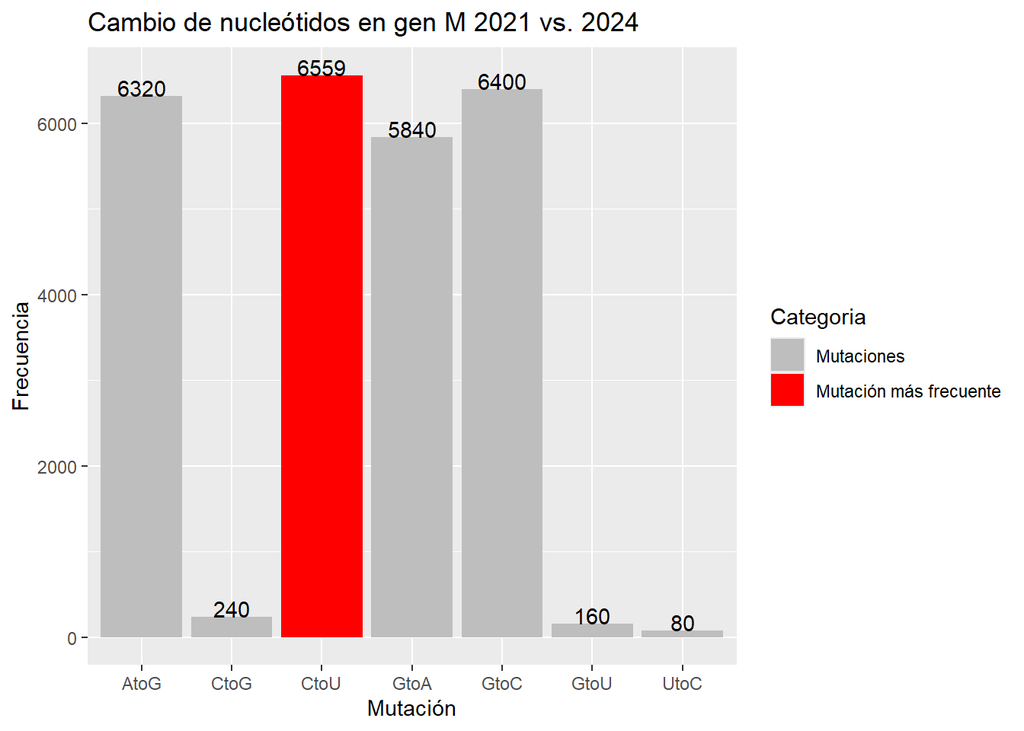

```r
frecuencias = datos2 %>%
  group_by(cambioAmino) %>%
  summarise(frecuencia = n()) %>%
  arrange(desc(frecuencia))

mutaciones_frecuentes = datos2 %>%
  count(mutacion, sort = TRUE) %>%
  filter(n == max(n))

datos2$resaltada= datos2$mutacion %in% mutaciones_frecuentes$mutacion

p = ggplot(datos2)
p = p + aes(x = mutacion, fill = resaltada, label = after_stat(count))
p = p + ggtitle(paste("Cambio de nucleótidos en gen M 2021 vs. 2024"))
p = p + labs(x = "Mutación", y = "Frecuencia", fill = "Categoria")
p = p + geom_bar(stat = "count")
p = p + geom_text(stat = "count", vjust = 0)
p = p + scale_fill_manual(values = c("gray", "red"), labels = c("Mutaciones","Mutación más frecuente"))
p
```

Al analizar el cambio de nucleótidos en el gen M entre las variantes BA.1 (2021) y JN.1 (2024), se observa que la mutación más frecuente es C→U, con 6,559 casos, seguida de cerca por A→G (6,320) y G→C (6,400). Esta predominancia del cambio C→U es un patrón común en virus de ARN y puede estar asociado con procesos como la desaminación y la presión selectiva del sistema inmune.

El hecho de que C→U sea la mutación más común sugiere que esta sustitución podría tener un papel importante en la adaptación del virus, posiblemente modificando regiones del gen M que afectan la estabilidad del virus o su capacidad para replicarse.

Con esto pudimos ver cómo el gen M también está sujeto a la evolución del virus, aunque con un número más limitado de mutaciones clave en comparación con el gen S.

### Gráfico de Pastel Nucleótidos Gen “M”

Al igual que en el análisis del gen “S” se realizo un gráfico de pastel para observar la distribución de mutaciones. Comparando las variantes BA.1 (2021) y JN.1 (2024), las mutaciones están altamente concentradas en pocos tipos de cambio, siendo C→U, G→C, A→G y G→A las más frecuentes, representando más del 95% del total. Esto indica que el gen M es estructuralmente conservado, pero ciertas mutaciones específicas han sido seleccionadas en la evolución del virus, posiblemente por su impacto en la estabilidad o eficiencia del ensamblaje viral.

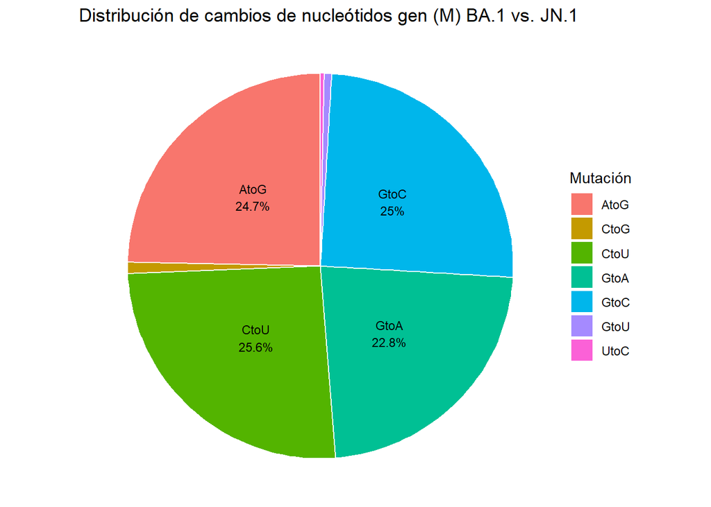

```r
frecuencias_nt = datos2 %>%
  count(mutacion, sort = TRUE) %>%
  mutate(porcentaje = n / sum(n) * 100)

frecuencias_nt$etiqueta = ifelse(frecuencias_nt$porcentaje > 3,
                                  paste0(frecuencias_nt$mutacion, "\n", round(frecuencias_nt$porcentaje, 1), "%"),"")
p_nt = ggplot(frecuencias_nt, aes(x = "", y = porcentaje, fill = mutacion)) +
  geom_col(width = 1, color = "white") +
  coord_polar(theta = "y") +
  geom_text(aes(label = etiqueta),
            position = position_stack(vjust = 0.5), size = 3) +
  labs(title = "Distribución de cambios de nucleótidos gen (M) BA.1 vs. JN.1",
       fill = "Mutación") +
  theme_void()
p_nt
```

## Cambio de Aminoácidos en el gen M

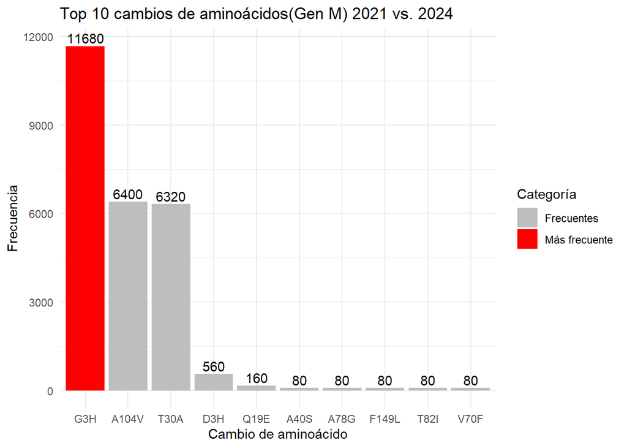

```r
dfgraph <- datos2 %>%
  group_by(cambioAmino) %>%
  summarise(
    mutacion = first(mutacion),
    cambioCodon = first(cambioCodon),
    pos = first(pos),
    gen = first(gen),
    cuenta = n(),
    .groups = "drop"
  ) %>%
  arrange(desc(cuenta)) %>%
  slice_head(n = 10)

max_val <- max(dfgraph$cuenta)
dfgraph$resaltado <- dfgraph$cuenta == max_val

p3 <- ggplot(dfgraph)
p3 <- p3 + aes(x = reorder(cambioAmino, -cuenta), y = cuenta, fill = resaltado, label = cuenta)
p3 <- p3 + ggtitle("Top 10 cambios de aminoácidos(Gen M) 2021 vs. 2024")
p3 <- p3 + labs(x = "Cambio de aminoácido", y = "Frecuencia", fill = "Categoría")
p3 <- p3 + geom_bar(stat = "identity")
p3 <- p3 + geom_text(stat = "identity", vjust = -0.3)
p3 <- p3 + scale_fill_manual(values = c("gray", "red"), labels = c("Frecuentes", "Más frecuente"))
p3 <- p3 + theme_minimal()
print(p3)
```

El análisis del gen M entre las variantes BA.1 (2021) y JN.1 (2024) revela que el cambio de aminoácido G3H se ha vuelto dominante, con 11680 casos, lo que indica una posible ventaja evolutiva para el virus. Este tipo de cambio tiene implicaciones directas en la vida cotidiana. El gen M codifica una proteína esencial para la estructura del virus, y una mutación tan frecuente puede significar que el virus se vuelve más eficiente para replicarse o resistir condiciones del entorno, incluyendo la respuesta del sistema inmune.

Con esto podemos entender que aunque muchas personas ya han sido vacunadas o infectadas anteriormente, el virus sigue adaptándose para sobrevivir. Cambios como G3H no solo representan una diferencia molecular, sino una estrategia del virus para mantenerse activo entre la población.

## Conclusiones

Finalmente después del análisis de las variantes BA.1 (2021) y JN.1 (2024) del SARS-CoV-2, se evidencia un proceso continuo de evolución del virus, impulsado por la presión inmunológica, la vacunación y la exposición previa de la población.

Al comparar los genes S (Spike) y M (Membrana), se observa que el gen S presenta una mayor diversidad de mutaciones, especialmente del tipo U→A y A→U, lo que indica una fuerte presión selectiva, ya que es el principal blanco de la respuesta inmune. En cambio, el gen M muestra un perfil más conservado, destacando la mutación C→U y un cambio dominante a nivel de aminoácidos (G3H), que podría influir en la estabilidad y ensamblaje del virus.

En el gen S, los cambios de aminoácidos más frecuentes afectan regiones estructurales críticas, como cisteínas relacionadas con puentes disulfuro, lo que podría facilitar el escape inmunológico. Estas mutaciones no solo son relevantes a nivel molecular, sino que han tenido un impacto directo en la salud pública, contribuyendo a nuevas olas de contagios, la necesidad de actualizar vacunas y estrategias de vigilancia.

### ¿Qué cambió en el virus a través de los años?

El virus no solo acumuló mutaciones, sino que se especializó. En 2021, las variantes como BA.1 eran resultado de mutaciones dispersas; en 2024, JN.1 representa una versión mucho más refinada del virus, con cambios funcionales en regiones clave que le permiten propagarse con mayor eficacia y evadir mejor el sistema inmune humano. En resumen, el SARS-CoV-2 ha evolucionado no solo para sobrevivir, sino para adaptarse mejor a un mundo inmunológicamente más preparado.